# JSaldana_LiveSession3assignment

### c. To make things easier to read, put par(las=2) before your plot to make the text perpendicular to the axis. Make a barplot of major_count. Make sure to label the title with something informative (check the vignette if you need), label the x and y axis, and make it any color other than grey. Assign the major_category labels to their respective bar. Flip the barplot horizontally so that bars extend to the right, not upward. All of these options can be done in a single pass of barplot(). Note: Itâs okay if itâs wider than the preview pane.

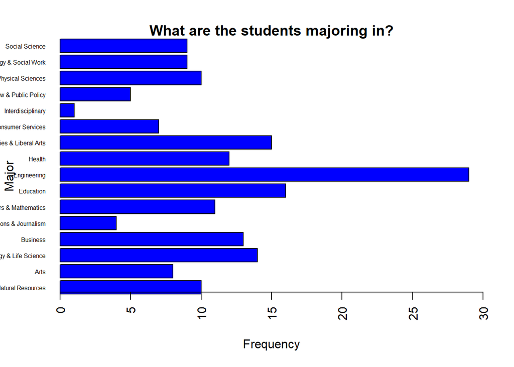

```r
par(las=2) #displays y text horizontal
par(mar=c(5.1,4.1,4.1,2.1)) #increase margins
barplot(as.numeric(major_count$Freq), #sources data
        main = "What are the students majoring in?", #title
        horiz = TRUE, #makes bar horizontal
        names.arg = major_count$Var1, #names of bars
        cex.names = 0.5, #reduce font size of names
        col="blue", #color of bars
        ylab = "Major", #axis title
        xlab = "Frequency", #axis title
        xlim = c(0, 30), #axis limit
        ylim = c(1,17)) #axis limit
```

```r
#creates barplot w/ specific attributes
```

### d. Write the fivethirtyeight data to a csv file. Make sure that it does not have row labels.

```r
write.csv(major_count, "major_count.csv", row.names=FALSE)
```

# **6. Codebook (30 points):**

### a. Start a new repository on GitHub for your SMU MSDS homework. On your local device, make sure there is a directory for Homework at the minimum; you are welcome to add whatever you would like to this repo in addition to your requirements here.

### b. Create a README.md file which explains the purpose of the repository, the topics included, the sources for the material you post, and contact information in case of questions. Remember, the one in the root directory should be general. You are welcome to make short READMEs for each assignment individually in other folders.

### c. In one (or more) of the nested directories, post your RMarkdown script, HTML file, and data from âfivethirtyeight.â Make sure that in your README or elsewhere that you credit fivethirtyeight in some way.

### d. In your RMarkdown script, please provide the link to this GitHub so the grader can see it.

```r
#https://github.com/javierjr55/SMU_MSDS/tree/master/MSDS_6306
```